# Lockdown MLM building

Andrew Mitchell

14/06/2020

```r
library(here)   # file path handline
library(MASS)   # Modelling
library(readxl)
library(dplyr)  # piping
library(glue)
library(lmerTest)
library(nlme)
library(MuMIn)
library(car)

ssid.data <- read_excel(here("data", "2020-06-14", "2020-04-28_Pre-Lockdown-London_combined.xlsx"))

# Set GroupID, SessionID, Location as factor type
ssid.data <- ssid.data %>% mutate_at(vars(GroupID, SessionID, LocationID,
                                          Lockdown),
                                     funs(as.factor))
ssid.data <- ssid.data %>% mutate_at(vars(Natural, overall, Pleasant,
                                          Eventful),
                                     funs(as.numeric))
```

For our starting acoustic variables, I need to cut it down to start. First, I’m removing all of the psychoacoustic_min variables. I’ll also remove the THD_freq features. The SII is not designed for environmental sound, so we’ll remove it. The LCeq_LAeq and LA10_LA90 have been producing terrible collinearity issues, so we’ll remove them up front.

```r
acoustic_vars = c('LZeq', 'LCeq', 'LAeq', 'LAmax', 'LA_5', 'LA_10', 'LA_50', 'LA_90', 'N', 'Nmax', 'N5', 'N10', 'N50', 'N90', 'N95', 'R', 'Rmax', 'R5', 'R10', 'R50', 'R90', 'R95', 'S', 'S.1', 'Smax', 'S5', 'S10', 'S50', 'S90', 'S95', 'T', 'Tmax', 'T5', 'T10', 'T50', 'T90', 'T95', 'FS', 'FSmax', 'FS5', 'FS10', 'FS50', 'FS90', 'FS95', 'THD', 'THDmax', 'THD5', 'THD10', 'THD50', 'THD90', 'THD95', 'I', 'Imax', 'I5', 'I10', 'I50', 'I90', 'I95', 'SIL.rms.', 'SIL.av.', 'SILmin', 'SILmax', 'SIL5', 'SIL10', 'SIL50', 'SIL90', 'SIL95', 'LA5_LA95', 'SpectralCentroid', 'PeakSpectralCentroid', 'HighFreqAvg', 'PeakHighFreqAvg', 'FS_slope', 'THD_slope', 'I_slope', 'LA_slope', 'LZ_slope', 'N_slope', 'R_slope', 'S_slope', 'T_slope')

dep_vars = c("Traffic", "Other", "Natural", "Human", "overall", "Pleasant", "Eventful")

# # Standardise
ssid.data <- ssid.data %>%
    mutate_at(acoustic_vars, ~(scale(.) %>% as.vector))


# Cutdown the dataset
ssid.data <- ssid.data[c("GroupID", "LocationID", dep_vars, acoustic_vars)]

london.compress <- ssid.data %>%
    group_by(GroupID) %>%
    summarize_at(.vars = c(dep_vars, acoustic_vars), mean)

london.compress['LocationID'] <- unique(ssid.data[c('GroupID', 'LocationID')])['LocationID']
london.compress <- data.frame(na.omit(london.compress))

# Global Mean Centering
for(variable in acoustic_vars){
    london.compress[variable] <- london.compress[variable] - mean(london.compress[[variable]])
}

# head(london.compress)
```

## Overall

### Feature selection for ‘overall’ model

```r
all.mod <- as.formula("overall ~ LZeq + LCeq + LAeq + LAmax + LA_10 + LA_50 + LA_90 + N + Nmax + N10 + N50 + N90 + R + R5 + R10 + R50 + R90 + R95 + S + Smax + S10 + S50 + S90 + T + Tmax + T10 + T50 + T90 + FS + FSmax + FS10 + FS50 + FS90 + FS95 + THD + THDmax + THD10 + THD50 + THD90 + I + Imax + I5 + I10 + I50 + I90 + I95 + SIL.rms. + SIL10 + SIL50 + SIL90 + LA5_LA95 + SpectralCentroid + PeakSpectralCentroid + HighFreqAvg + PeakHighFreqAvg + FS_slope + THD_slope + I_slope + LA_slope + LZ_slope + N_slope + R_slope + S_slope + T_slope + (1|LocationID)")


full.model <- lmerTest::lmer(all.mod, data = london.compress)
step.model <- lmerTest::step(full.model, direction = 'both', reduce.random=F)
print(step.model)
```

```
## Backward reduced random-effect table:
##
##                  Eliminated npar  logLik    AIC    LRT Df Pr(>Chisq)
## <none>                        67 -725.71 1585.4
## (1 | LocationID)          0   66 -736.47 1605.0 21.521  1  3.499e-06 ***
## ---
## Signif. codes:  0 '***' 0.001 '**' 0.01 '*' 0.05 '.' 0.1 ' ' 1
##
## Backward reduced fixed-effect table:
## Degrees of freedom method: Satterthwaite
##
##                      Eliminated Sum Sq Mean Sq NumDF  DenDF F value    Pr(>F)
## R5                            1 0.0001  0.0001     1 537.00  0.0001 0.9906049
## LA_90                         2 0.0005  0.0005     1 542.21  0.0009 0.9764018
## I95                           3 0.0013  0.0013     1 539.65  0.0023 0.9613782
## LZeq                          4 0.0012  0.0012     1 543.30  0.0023 0.9620576
## HighFreqAvg                   5 0.0019  0.0019     1 547.45  0.0034 0.9533651
## I10                           6 0.0038  0.0038     1 540.82  0.0069 0.9339695
## S                             7 0.0066  0.0066     1 548.13  0.0120 0.9127634
## THD90                         8 0.0141  0.0141     1 502.22  0.0258 0.8724756
## SIL50                         9 0.0142  0.0142     1 549.10  0.0261 0.8717106
## PeakHighFreqAvg              10 0.0227  0.0227     1 551.45  0.0417 0.8383112
## THD10                        11 0.0279  0.0279     1 552.21  0.0514 0.8207866
## LA_slope                     12 0.0313  0.0313     1 552.70  0.0578 0.8100566
## PeakSpectralCentroid         13 0.0408  0.0408     1 550.71  0.0755 0.7836228
## THD50                        14 0.0276  0.0276     1 278.07  0.0511 0.8213394
## N                            15 0.0442  0.0442     1 556.50  0.0820 0.7747371
## SIL90                        16 0.0400  0.0400     1 559.00  0.0744 0.7851735
## Imax                         17 0.0417  0.0417     1 555.60  0.0776 0.7806772
## Tmax                         18 0.0508  0.0508     1 554.52  0.0946 0.7585497
## THDmax                       19 0.0619  0.0619     1 554.16  0.1155 0.7340996
## R                            20 0.0946  0.0946     1 556.19  0.1768 0.6742651
## N50                          21 0.1006  0.1006     1 563.46  0.1883 0.6644841
## I50                          22 0.1371  0.1371     1 560.29  0.2571 0.6123358
## THD                          23 0.1652  0.1652     1 565.94  0.3100 0.5778897
## R10                          24 0.1820  0.1820     1 562.11  0.3419 0.5589836
## S10                          25 0.1729  0.1729     1 564.76  0.3252 0.5687372
## I_slope                      26 0.2199  0.2199     1 563.27  0.4141 0.5201391
## N10                          27 0.2322  0.2322     1 569.94  0.4376 0.5085298
## LAmax                        28 0.2007  0.2007     1 565.93  0.3788 0.5385070
```

[output cut: 92 more lines]

```
## FS90                 **
## FS95                 **
## I                    *
## I5                   *
## SIL.rms.             ***
## FS_slope             *
## N_slope              *
## R_slope              **
## S_slope              **
## ---
## Signif. codes:  0 '***' 0.001 '**' 0.01 '*' 0.05 '.' 0.1 ' ' 1
##
## Model found:
## overall ~ LAeq + Nmax + R90 + Smax + FS90 + FS95 + I + I5 + SIL.rms. +
##     FS_slope + N_slope + R_slope + S_slope + (1 | LocationID)
```

The final model selectd is:

```r
selected.mod <- get_model(step.model)
summary(selected.mod)
```

```
## Linear mixed model fit by REML. t-tests use Satterthwaite's method [
## lmerModLmerTest]
## Formula:
## overall ~ LAeq + Nmax + R90 + Smax + FS90 + FS95 + I + I5 + SIL.rms. +
##     FS_slope + N_slope + R_slope + S_slope + (1 | LocationID)
##    Data: london.compress
##
## REML criterion at convergence: 1406.8
##
## Scaled residuals:
##     Min      1Q  Median      3Q     Max
## -3.4553 -0.5879  0.0913  0.6560  2.2430
##
## Random effects:
##  Groups     Name        Variance Std.Dev.
##  LocationID (Intercept) 0.1516   0.3893
##  Residual               0.5363   0.7324
## Number of obs: 609, groups:  LocationID, 11
##
## Fixed effects:
##              Estimate Std. Error        df t value Pr(>|t|)
## (Intercept)   3.64936    0.12158   8.53740  30.017 5.89e-10 ***
## LAeq          1.53905    0.43231 594.54489   3.560 0.000400 ***
## Nmax         -0.23396    0.10161 594.94547  -2.303 0.021649 *
## R90          -0.33746    0.09824 541.93791  -3.435 0.000638 ***
## Smax          0.18677    0.06205 592.26176   3.010 0.002722 **
## FS90         -1.07512    0.35328 585.11172  -3.043 0.002445 **
## FS95          1.08798    0.34768 586.08693   3.129 0.001840 **
## I             0.19238    0.09179 590.46944   2.096 0.036515 *
## I5           -0.18929    0.08587 588.12610  -2.204 0.027883 *
## SIL.rms.     -1.44833    0.39939 594.96587  -3.626 0.000312 ***
## FS_slope      0.32418    0.14504 594.23756   2.235 0.025782 *
## N_slope      -0.24926    0.12303 594.70501  -2.026 0.043216 *
## R_slope      -0.42452    0.15052 592.13948  -2.820 0.004958 **
## S_slope       0.40583    0.13355 594.17295   3.039 0.002480 **
## ---
## Signif. codes:  0 '***' 0.001 '**' 0.01 '*' 0.05 '.' 0.1 ' ' 1
```

```
##
## Correlation matrix not shown by default, as p = 14 > 12.
## Use print(x, correlation=TRUE)  or
##     vcov(x)        if you need it
```

```r
r.squaredGLMM(selected.mod)
```

```
##            R2m       R2c
## [1,] 0.1314412 0.3228206
```

overall ~ LAeq + Nmax + R90 + Smax + FS90 + FS95 + I + I5 + SIL.rms. + FS_slope + N_slope + R_slope + S_slope + (1|LocationID)

From here we can investigate more thorougly, starting with multicollinearity and VIF

### Multicollinearity

```r
vif(selected.mod, data = london.compress)
```

```
##       LAeq       Nmax        R90       Smax       FS90       FS95          I
##  89.975770   6.425448   4.589846   3.371462 112.065600 109.196179   7.376161
##         I5   SIL.rms.   FS_slope    N_slope    R_slope    S_slope
##   6.340094  76.014417   8.047078   8.046272   8.708805   8.340961
```

LAeq, FS90, FS95, SIL.rms. all have VIF above 10

Begin by removing: * FS90 * SIL.rms.

```r
new.mod <- lmer(overall ~ LAeq + Nmax + R90 + Smax + FS95 + I + I5 + FS_slope + N_slope + R_slope + S_slope + (1|LocationID), data = london.compress)
r.squaredGLMM(new.mod)
```

```
##             R2m       R2c
## [1,] 0.08937744 0.3074626
```

```r
vif(new.mod, data = london.compress)
```

```
##     LAeq     Nmax      R90     Smax     FS95        I       I5 FS_slope
## 6.498798 6.104322 4.076789 3.037309 2.282493 7.257763 6.280005 7.906918
##  N_slope  R_slope  S_slope
## 7.480011 8.645623 8.315244
```

No features have VIF > 10. The highest VIF features are the _slope features.

### Predicting Overall responses and Checking prediction behaviour

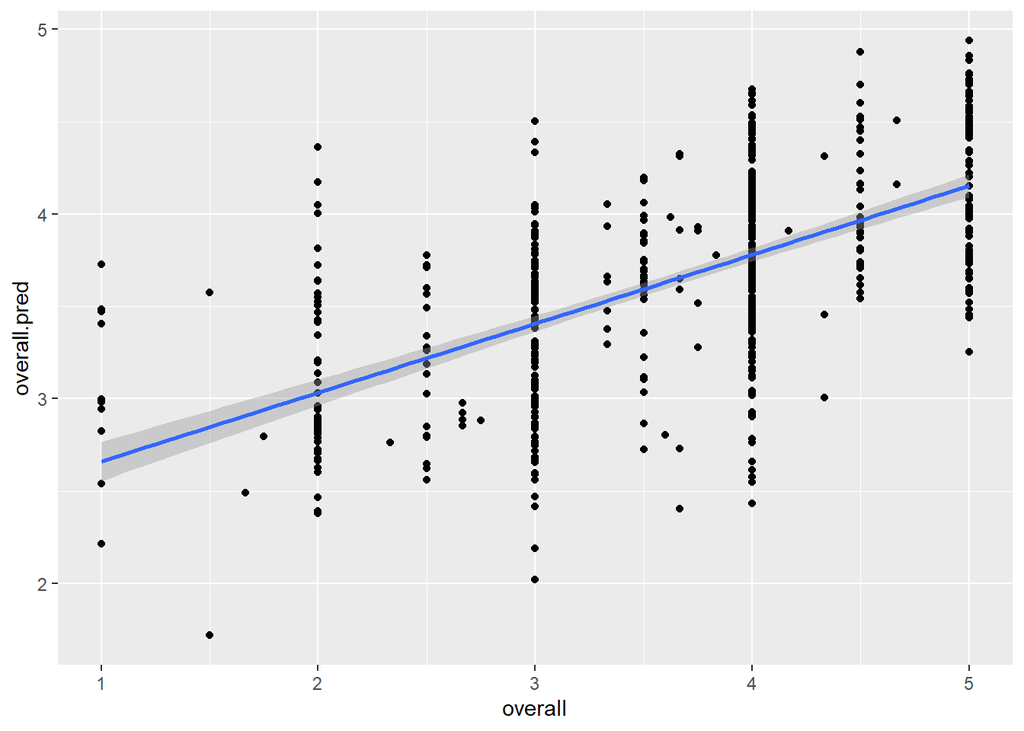

```r
library(ggplot2)
london.compress$overall.pred <- predict(new.mod, newdata = london.compress)
ggplot(london.compress, aes(x=overall, y=overall.pred)) + geom_point() +
    geom_smooth(method=lm)
```

```r
cor(london.compress$overall, london.compress$overall.pred)
```

```
## [1] 0.6191067
```

```r
var(london.compress$overall, london.compress$overall.pred)
```

```
## [1] 0.323602
```

```r
print(summary(london.compress$overall))
```

```
##    Min. 1st Qu.  Median    Mean 3rd Qu.    Max.
##   1.000   3.000   4.000   3.649   4.000   5.000
```

```r
print(summary(london.compress$overall.pred))
```

```
##    Min. 1st Qu.  Median    Mean 3rd Qu.    Max.
##   1.717   3.282   3.680   3.649   4.008   4.939
```

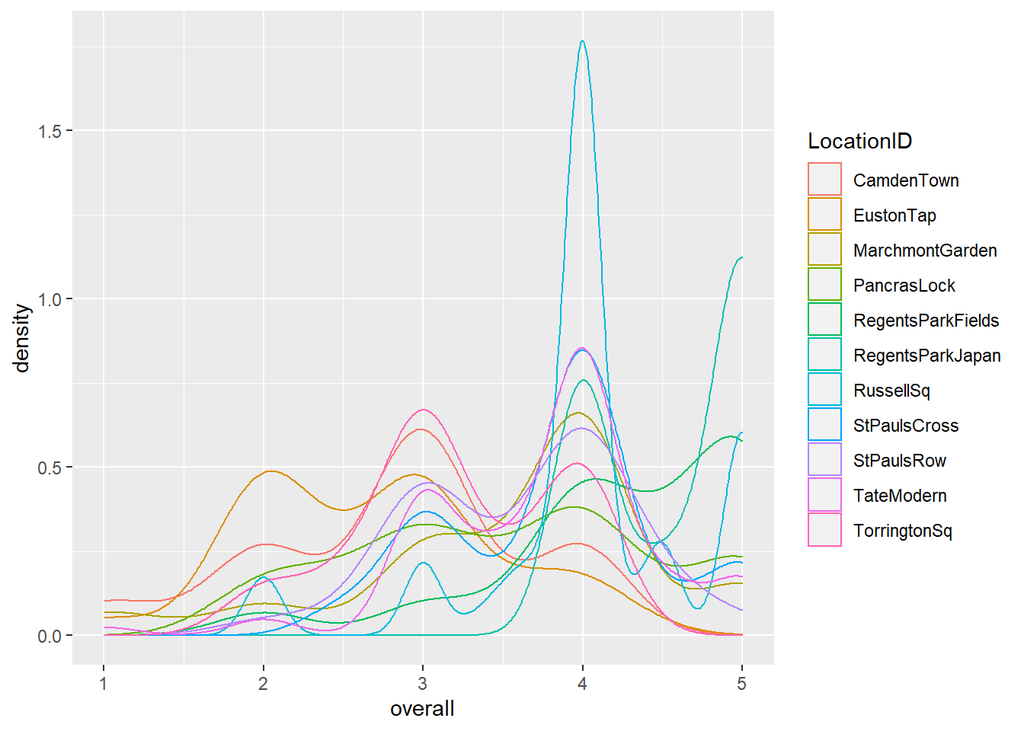

```r
ggplot(london.compress, aes(x = overall, color=LocationID)) +
    geom_density()
```

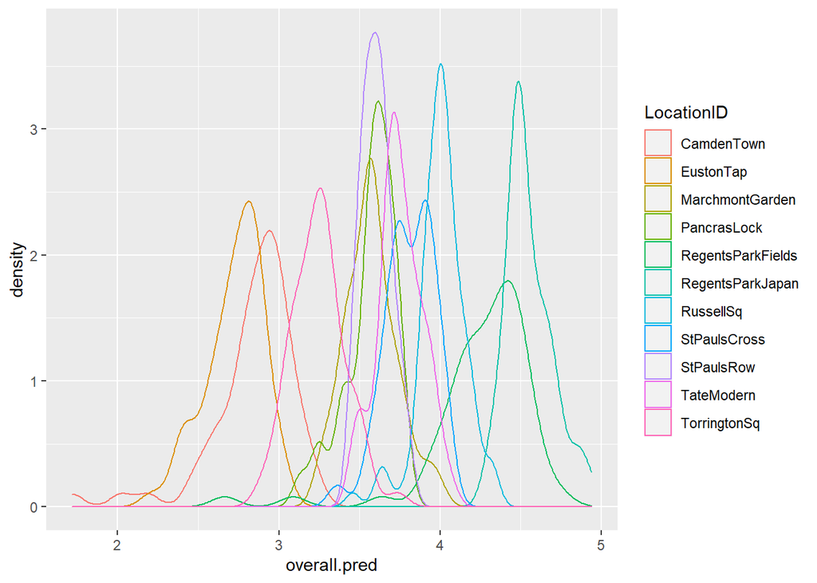

```r
ggplot(london.compress, aes(x = overall.pred, color=LocationID)) +
    geom_density()
```

## Pleasant (complex)

### Feature selection for Pleasant model

```r
all.mod <- as.formula("Pleasant ~ LZeq + LCeq + LAeq + LAmax + LA_10 + LA_50 + LA_90 + N + Nmax + N10 + N50 + N90 + R + R5 + R10 + R50 + R90 + R95 + S + Smax + S10 + S50 + S90 + T + Tmax + T10 + T50 + T90 + FS + FSmax + FS10 + FS50 + FS90 + FS95 + THD + THDmax + THD10 + THD50 + THD90 + I + Imax + I5 + I10 + I50 + I90 + I95 + SIL.rms. + SIL10 + SIL50 + SIL90 + LA5_LA95 + SpectralCentroid + PeakSpectralCentroid + HighFreqAvg + PeakHighFreqAvg + FS_slope + THD_slope + I_slope + LA_slope + LZ_slope + N_slope + R_slope + S_slope + T_slope + (1|LocationID)")

full.model <- lmerTest::lmer(all.mod, data = london.compress)
step.model <- lmerTest::step(full.model, direction = "both", reduce.random = F)
print(step.model)
```

```
## Backward reduced random-effect table:
##
##                  Eliminated npar  logLik    AIC    LRT Df Pr(>Chisq)
## <none>                        67 -230.37 594.73
## (1 | LocationID)          0   66 -243.10 618.20 25.473  1  4.487e-07 ***
## ---
## Signif. codes:  0 '***' 0.001 '**' 0.01 '*' 0.05 '.' 0.1 ' ' 1
##
## Backward reduced fixed-effect table:
## Degrees of freedom method: Satterthwaite
##
##                      Eliminated  Sum Sq Mean Sq NumDF  DenDF F value    Pr(>F)
## I90                           1 0.00003 0.00003     1 536.34  0.0004  0.984365
## THD10                         2 0.00026 0.00026     1 544.34  0.0029  0.957019
## I                             3 0.00037 0.00037     1 534.80  0.0042  0.948403
## I10                           4 0.00032 0.00032     1 540.76  0.0036  0.952289
## N10                           5 0.00058 0.00058     1 542.47  0.0066  0.935268
## S_slope                       6 0.00076 0.00076     1 548.50  0.0087  0.925880
## R_slope                       7 0.00079 0.00079     1 544.56  0.0090  0.924484
## R5                            8 0.00160 0.00160     1 542.94  0.0182  0.892873
## FS                            9 0.00170 0.00170     1 543.59  0.0194  0.889266
## I_slope                      10 0.00211 0.00211     1 550.42  0.0240  0.876820
## LZ_slope                     11 0.00226 0.00226     1 527.55  0.0259  0.872319
## SIL90                        12 0.00384 0.00384     1 554.11  0.0440  0.833961
## LA5_LA95                     13 0.00366 0.00366     1 546.97  0.0419  0.837792
## Imax                         14 0.00501 0.00501     1 547.54  0.0575  0.810530
## N90                          15 0.00930 0.00930     1 557.98  0.1070  0.743675
## SIL.rms.                     16 0.01062 0.01062     1 553.70  0.1224  0.726586
## FSmax                        17 0.01269 0.01269     1 550.88  0.1466  0.701966
## FS50                         18 0.01095 0.01095     1 552.57  0.1267  0.722021
## Nmax                         19 0.01125 0.01125     1 552.60  0.1303  0.718282
## HighFreqAvg                  20 0.01353 0.01353     1 562.99  0.1570  0.692107
## S                            21 0.01785 0.01785     1 561.23  0.2074  0.648973
## LA_slope                     22 0.02146 0.02146     1 559.33  0.2496  0.617584
## LCeq                         23 0.02337 0.02337     1 528.64  0.2722  0.602086
## THD                          24 0.02083 0.02083     1 566.91  0.2429  0.622280
## T90                          25 0.02120 0.02120     1 565.00  0.2476  0.618988
## I5                           26 0.02641 0.02641     1 563.04  0.3088  0.578661
## PeakSpectralCentroid         27 0.02534 0.02534     1 566.08  0.2965  0.586273
## R10                          28 0.02939 0.02939     1 561.10  0.3442  0.557631
```

[output cut: 92 more lines]

```
## S90
## LA_50                ***
## R90                  ***
## FS10                 **
## FS90                 **
## FS95                 **
## THDmax               **
## I50                  **
## SIL50                ***
## ---
## Signif. codes:  0 '***' 0.001 '**' 0.01 '*' 0.05 '.' 0.1 ' ' 1
##
## Model found:
## Pleasant ~ LA_50 + R90 + FS10 + FS90 + FS95 + THDmax + I50 +
##     SIL50 + (1 | LocationID)
```

The Selected model is:

```r
selected.mod <- get_model(step.model)
summary(selected.mod)
```

```
## Linear mixed model fit by REML. t-tests use Satterthwaite's method [
## lmerModLmerTest]
## Formula: Pleasant ~ LA_50 + R90 + FS10 + FS90 + FS95 + THDmax + I50 +
##     SIL50 + (1 | LocationID)
##    Data: london.compress
##
## REML criterion at convergence: 305.9
##
## Scaled residuals:
##     Min      1Q  Median      3Q     Max
## -4.6588 -0.5564  0.1385  0.6792  2.1751
##
## Random effects:
##  Groups     Name        Variance Std.Dev.
##  LocationID (Intercept) 0.03050  0.1746
##  Residual               0.08648  0.2941
## Number of obs: 609, groups:  LocationID, 11
##
## Fixed effects:
##              Estimate Std. Error        df t value Pr(>|t|)
## (Intercept)   0.26128    0.05415   9.08524   4.825 0.000915 ***
## LA_50         0.90248    0.18104 598.77192   4.985 8.12e-07 ***
## R90          -0.23353    0.04819 557.75946  -4.846 1.64e-06 ***
## FS10          0.04208    0.01506 592.37432   2.795 0.005360 **
## FS90         -0.45475    0.13800 593.41244  -3.295 0.001042 **
## FS95          0.40377    0.13617 594.28627   2.965 0.003147 **
## THDmax       -0.05192    0.01847 584.43494  -2.811 0.005108 **
## I50           0.04987    0.01856 596.11122   2.686 0.007430 **
## SIL50        -0.75519    0.15429 597.50295  -4.895 1.27e-06 ***
## ---
## Signif. codes:  0 '***' 0.001 '**' 0.01 '*' 0.05 '.' 0.1 ' ' 1
##
## Correlation of Fixed Effects:
##        (Intr) LA_50  R90    FS10   FS90   FS95   THDmax I50
## LA_50   0.018
## R90    -0.038 -0.700
## FS10    0.001  0.250 -0.107
## FS90   -0.005  0.003  0.147 -0.106
## FS95    0.007 -0.024 -0.150  0.043 -0.988
## THDmax  0.009 -0.069 -0.080  0.047  0.033 -0.028
## I50    -0.001  0.151 -0.273 -0.116 -0.168  0.092 -0.058
## SIL50  -0.012 -0.978  0.573 -0.265 -0.045  0.062  0.049 -0.093
```

```r
r.squaredGLMM(selected.mod)
```

```
##            R2m      R2c
## [1,] 0.1214819 0.350519
```

Pleasant ~ LA_50 + R90 + FS10 + FS90 + FS95 + THDmax + I50 + SIL50

### Multicollinearity

```r
vif(selected.mod, data = london.compress)
```

```
##      LA_50        R90       FS10       FS90       FS95     THDmax        I50
##  92.009065   6.727784   1.699953 105.874179 103.702085   1.215241   2.033510
##      SIL50
##  67.595945
```

LA_50, FS90, FS95, SIL50 all have VIF > 10

Remove: * FS90 * SIL50

```r
new.mod <- lmer(Pleasant ~ LA_50 + R90 + FS10 + FS95 + THDmax + I50 + (1|LocationID), data = london.compress)
r.squaredGLMM(new.mod)
```

```
##             R2m       R2c
## [1,] 0.06896483 0.3318611
```

```r
vif(new.mod, data = london.compress)
```

```
##    LA_50      R90     FS10     FS95   THDmax      I50
## 3.882372 4.308910 1.556704 2.395664 1.208563 1.954197
```

No features have VIF > 10.

### Predicting Pleasant responses and checking prediction behaviour

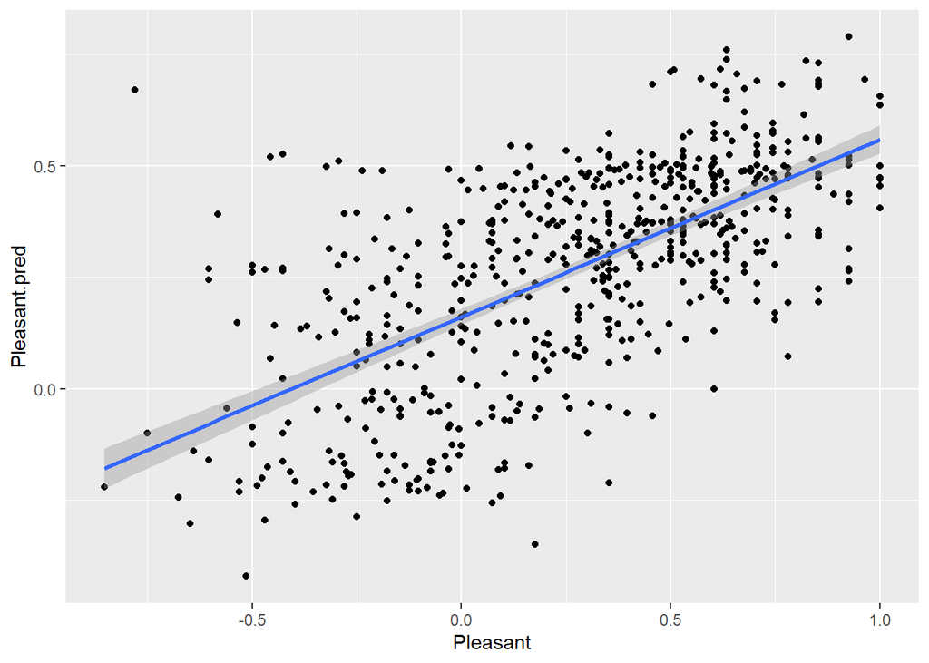

```r
london.compress$Pleasant.pred <- predict(new.mod, newdata = london.compress)
ggplot(london.compress, aes(x=Pleasant, y=Pleasant.pred)) + geom_point() +
    geom_smooth(method=lm)
```

```r
cor(london.compress$Pleasant, london.compress$Pleasant.pred)
```

```
## [1] 0.6381795
```

```r
var(london.compress$Pleasant, london.compress$Pleasant.pred)
```

```
## [1] 0.05965822
```

```r
print(summary(london.compress$Pleasant))
```

```
##     Min.  1st Qu.   Median     Mean  3rd Qu.     Max.
## -0.85355 -0.02145  0.31694  0.26820  0.57322  1.00000
```

```r
print(summary(london.compress$Pleasant.pred))
```

```
##    Min. 1st Qu.  Median    Mean 3rd Qu.    Max.
## -0.4202  0.1212  0.3100  0.2682  0.4565  0.7890
```

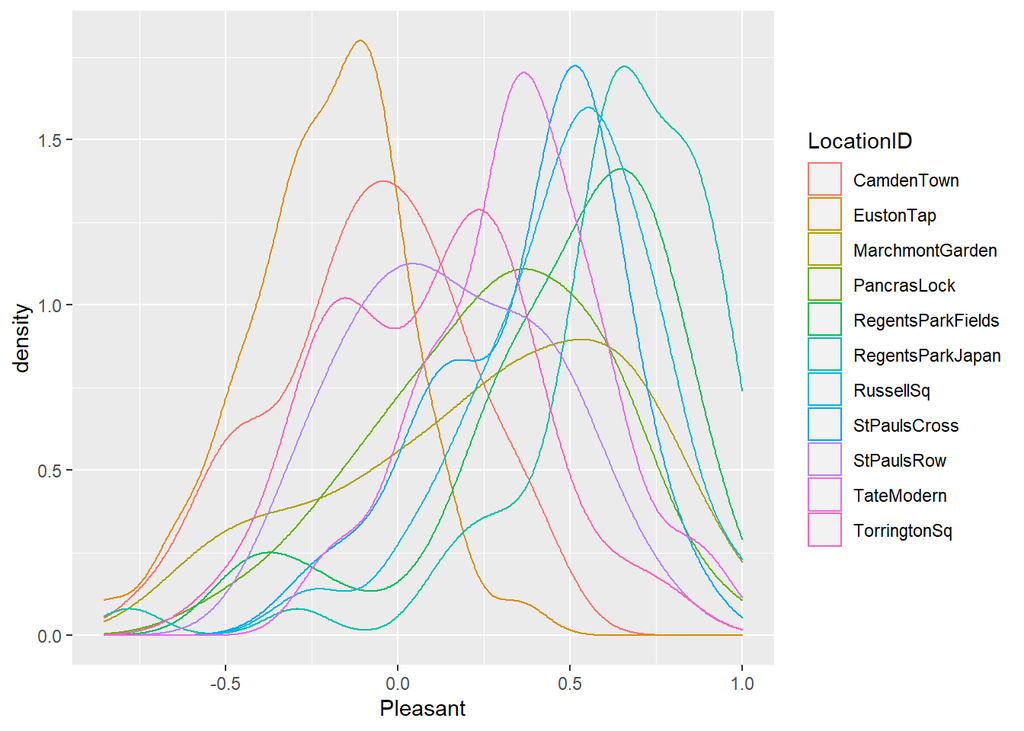

```r
ggplot(london.compress, aes(x = Pleasant, color=LocationID)) +
    geom_density()
```

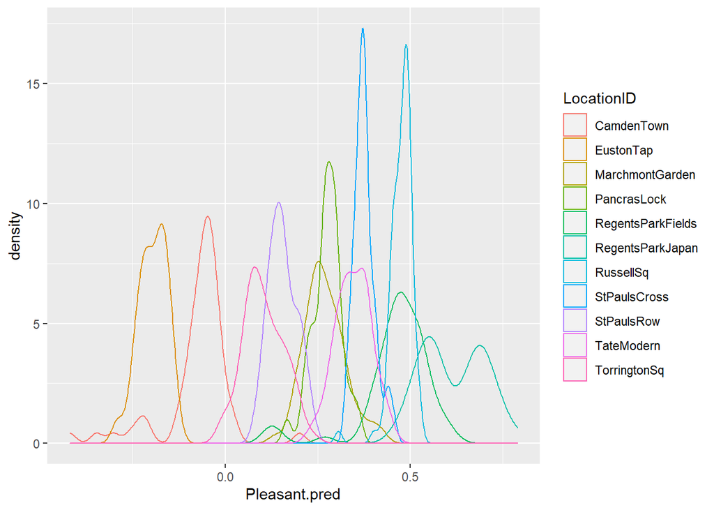

```r
ggplot(london.compress, aes(x = Pleasant.pred, color = LocationID)) +
    geom_density()
```

## Eventful (complex)

### Feature selection for Eventful model

```r
all.mod <- as.formula("Eventful ~ LZeq + LCeq + LAeq + LAmax + LA_10 + LA_50 + LA_90 + N + Nmax + N10 + N50 + N90 + R + R5 + R10 + R50 + R90 + R95 + S + Smax + S10 + S50 + S90 + T + Tmax + T10 + T50 + T90 + FS + FSmax + FS10 + FS50 + FS90 + FS95 + THD + THDmax + THD10 + THD50 + THD90 + I + Imax + I5 + I10 + I50 + I90 + I95 + SIL.rms. + SIL10 + SIL50 + SIL90 + LA5_LA95 + SpectralCentroid + PeakSpectralCentroid + HighFreqAvg + PeakHighFreqAvg + FS_slope + THD_slope + I_slope + LA_slope + LZ_slope + N_slope + R_slope + S_slope + T_slope + (1|LocationID)")

full.model <- lmerTest::lmer(all.mod, data = london.compress)
step.model <- lmerTest::step(full.model, direction = "both", reduce.random = F)
print(step.model)
```

```
## Backward reduced random-effect table:
##
##                  Eliminated npar  logLik    AIC    LRT Df Pr(>Chisq)
## <none>                        67 -144.29 422.58
## (1 | LocationID)          0   66 -149.39 430.77 10.197  1   0.001406 **
## ---
## Signif. codes:  0 '***' 0.001 '**' 0.01 '*' 0.05 '.' 0.1 ' ' 1
##
## Backward reduced fixed-effect table:
## Degrees of freedom method: Satterthwaite
##
##                      Eliminated  Sum Sq Mean Sq NumDF  DenDF F value    Pr(>F)
## I50                           1 0.00001 0.00001     1 536.10  0.0002 0.9889527
## THD50                         2 0.00002 0.00002     1 415.21  0.0003 0.9870867
## I90                           3 0.00002 0.00002     1 543.09  0.0003 0.9852766
## T                             4 0.00007 0.00007     1 546.68  0.0010 0.9745497
## FS95                          5 0.00048 0.00048     1 541.90  0.0074 0.9314217
## PeakSpectralCentroid          6 0.00079 0.00079     1 437.62  0.0121 0.9122888
## R50                           7 0.00129 0.00129     1 549.67  0.0198 0.8881418
## S90                           8 0.00212 0.00212     1 550.98  0.0326 0.8568869
## FS                            9 0.00273 0.00273     1 547.96  0.0420 0.8377012
## THDmax                       10 0.00327 0.00327     1 552.97  0.0505 0.8222695
## FSmax                        11 0.00329 0.00329     1 547.65  0.0509 0.8215166
## LA5_LA95                     12 0.00336 0.00336     1 552.83  0.0521 0.8195043
## R10                          13 0.00339 0.00339     1 549.48  0.0526 0.8186736
## N10                          14 0.00564 0.00564     1 553.92  0.0878 0.7671457
## N                            15 0.00363 0.00363     1 557.63  0.0565 0.8122203
## LA_slope                     16 0.00748 0.00748     1 558.92  0.1166 0.7328936
## N50                          17 0.00813 0.00813     1 534.45  0.1270 0.7217343
## LA_50                        18 0.00906 0.00906     1 557.72  0.1417 0.7067702
## THD90                        19 0.00903 0.00903     1 227.02  0.1414 0.7072699
## I10                          20 0.00969 0.00969     1 561.92  0.1519 0.6968821
## PeakHighFreqAvg              21 0.01200 0.01200     1 563.68  0.1884 0.6644295
## LZ_slope                     22 0.01318 0.01318     1 451.38  0.2072 0.6492190
## T90                          23 0.01513 0.01513     1 565.61  0.2381 0.6257485
## R90                          24 0.02685 0.02685     1 566.47  0.4233 0.5155507
## SIL50                        25 0.03009 0.03009     1 564.65  0.4748 0.4910768
## SpectralCentroid             26 0.03461 0.03461     1 227.62  0.5466 0.4604671
## Imax                         27 0.03265 0.03265     1 569.99  0.5161 0.4728091
## N90                          28 0.03984 0.03984     1 462.32  0.6307 0.4275224
```

[output cut: 92 more lines]

```
## Smax                 **
## S50                  ***
## FS10                 **
## THD                  *
## SIL10                **
## SIL90                **
## FS_slope             ***
## I_slope              *
## R_slope              *
## ---
## Signif. codes:  0 '***' 0.001 '**' 0.01 '*' 0.05 '.' 0.1 ' ' 1
##
## Model found:
## Eventful ~ LA_90 + S + Smax + S50 + FS10 + THD + SIL10 + SIL90 +
##     FS_slope + I_slope + R_slope + (1 | LocationID)
```

The Selected model is:

```r
selected.mod <- get_model(step.model)
summary(selected.mod)
```

```
## Linear mixed model fit by REML. t-tests use Satterthwaite's method [
## lmerModLmerTest]
## Formula: Eventful ~ LA_90 + S + Smax + S50 + FS10 + THD + SIL10 + SIL90 +
##     FS_slope + I_slope + R_slope + (1 | LocationID)
##    Data: london.compress
##
## REML criterion at convergence: 124.1
##
## Scaled residuals:
##     Min      1Q  Median      3Q     Max
## -4.0747 -0.6437 -0.0265  0.6928  2.9250
##
## Random effects:
##  Groups     Name        Variance Std.Dev.
##  LocationID (Intercept) 0.004655 0.06823
##  Residual               0.063761 0.25251
## Number of obs: 609, groups:  LocationID, 11
##
## Fixed effects:
##              Estimate Std. Error        df t value Pr(>|t|)
## (Intercept)   0.11386    0.02316   9.18621   4.915 0.000781 ***
## LA_90        -0.31506    0.10874 584.05730  -2.897 0.003904 **
## S             0.15402    0.06454 595.68746   2.386 0.017334 *
## Smax         -0.07410    0.02860 587.04751  -2.591 0.009806 **
## S50          -0.20572    0.05605 522.31292  -3.670 0.000267 ***
## FS10         -0.03171    0.01145 582.68559  -2.770 0.005793 **
## THD          -0.02718    0.01142 517.01264  -2.379 0.017706 *
## SIL10         0.10888    0.03582 526.50671   3.040 0.002485 **
## SIL90         0.35071    0.12229 558.92038   2.868 0.004288 **
## FS_slope      0.16117    0.04701 595.70373   3.429 0.000648 ***
## I_slope      -0.05319    0.02246 594.87855  -2.368 0.018216 *
## R_slope      -0.11354    0.04666 596.93907  -2.433 0.015257 *
## ---
## Signif. codes:  0 '***' 0.001 '**' 0.01 '*' 0.05 '.' 0.1 ' ' 1
##
## Correlation of Fixed Effects:
##          (Intr) LA_90  S      Smax   S50    FS10   THD    SIL10  SIL90  FS_slp
## LA_90    -0.011
## S         0.004 -0.122
## Smax     -0.016  0.171 -0.816
## S50       0.016  0.253 -0.878  0.614
## FS10      0.012  0.168 -0.059 -0.139  0.175
## THD      -0.019  0.088 -0.032  0.109 -0.037  0.007
## SIL10     0.006 -0.028 -0.277 -0.010  0.319 -0.086 -0.089
## SIL90     0.005 -0.945  0.204 -0.171 -0.401 -0.167 -0.065 -0.231
## FS_slope -0.009 -0.094 -0.043  0.069  0.071 -0.070 -0.068 -0.009  0.042
## I_slope  -0.004  0.031 -0.053  0.023  0.054 -0.038  0.000 -0.053 -0.022 -0.257
## R_slope   0.012  0.070  0.074 -0.089 -0.112  0.080  0.052  0.084 -0.026 -0.836
##          I_slop
## LA_90
## S
## Smax
## S50
## FS10
## THD
## SIL10
## SIL90
## FS_slope
## I_slope
## R_slope  -0.160
```

```r
r.squaredGLMM(selected.mod)
```

```
##            R2m      R2c
## [1,] 0.1750519 0.231184
```

Eventful ~ LA_90 + S + Smax + S50 + FS10 + THD + SIL10 + SIL90 + FS_slope + I_slope + R_slope + (1|LocationID)

### Multicollinearity

```r
vif(selected.mod, data = london.compress)
```

```
##     LA_90         S      Smax       S50      FS10       THD     SIL10     SIL90
## 56.882972 23.366819  6.292248 15.405513  1.351748  1.094145  6.323659 70.819438
##  FS_slope   I_slope   R_slope
##  7.135696  2.162837  7.085285
```

LA_90, S, S50, SIL90 all have VIF > 10

Remove: * SIL90 * S * R_slope

```r
new.mod <- lmer(Eventful ~ LA_90 + Smax + S50 + FS10 + THD + SIL10 + FS_slope + I_slope + (1|LocationID), data = london.compress)
r.squaredGLMM(new.mod)
```

```
##            R2m       R2c
## [1,] 0.1489423 0.2043203
```

```r
vif(new.mod, data = london.compress)
```

```
##    LA_90     Smax      S50     FS10      THD    SIL10 FS_slope  I_slope
## 5.694269 2.097830 2.677092 1.304567 1.084956 5.613877 2.141546 2.103003
```

No features have VIF > 10.

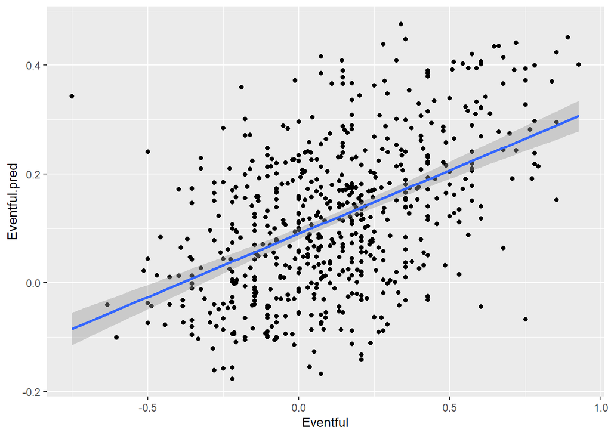

```r
london.compress$Eventful.pred <- predict(new.mod, newdata = london.compress)
ggplot(london.compress, aes(x=Eventful, y=Eventful.pred)) + geom_point() +
    geom_smooth(method=lm)
```

```r
cor(london.compress$Eventful, london.compress$Eventful.pred)
```

```
## [1] 0.4928019
```

```r
var(london.compress$Eventful, london.compress$Eventful.pred)
```

```
## [1] 0.01963619
```

```r
print(summary(london.compress$Eventful))
```

```
##     Min.  1st Qu.   Median     Mean  3rd Qu.     Max.
## -0.75000 -0.08839  0.10355  0.11779  0.29289  0.92678
```

```r
print(summary(london.compress$Eventful.pred))
```

```
##     Min.  1st Qu.   Median     Mean  3rd Qu.     Max.
## -0.17715  0.01279  0.11513  0.11779  0.20990  0.47536
```

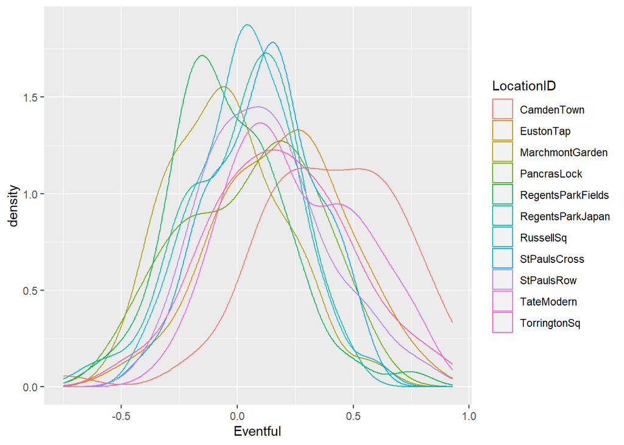

```r
ggplot(london.compress, aes(x = Eventful, color=LocationID)) +
    geom_density()
```

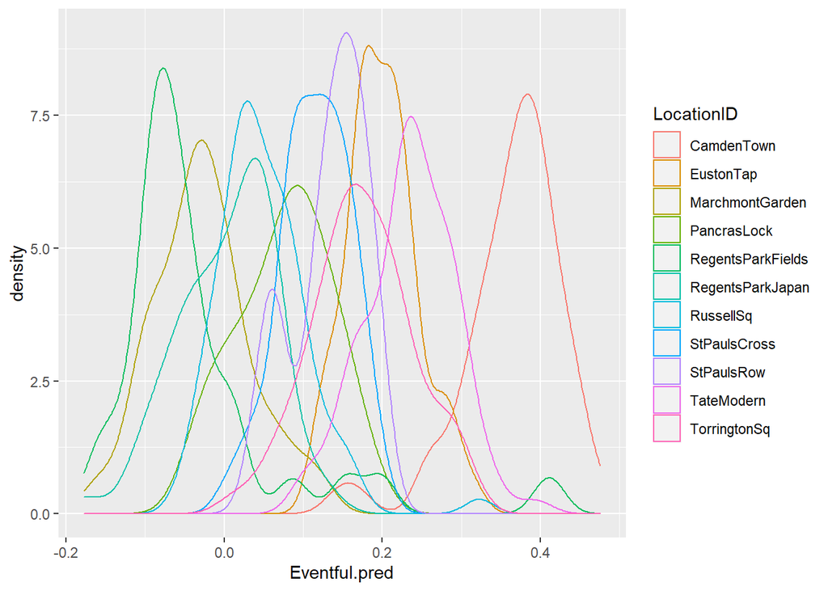

```r
ggplot(london.compress, aes(x = Eventful.pred, color = LocationID)) +
    geom_density()
```